# stmn2_edgeR

# STMN2 Screen

## Prepare data for DGEList object for edgeR

```
##     sgRNA               Gene              Low_rep1        Low_rep2
##  Length:21199       Length:21199       Min.   :    0   Min.   :    0
##  Class :character   Class :character   1st Qu.: 2060   1st Qu.: 2030
##  Mode  :character   Mode  :character   Median : 3491   Median : 3512
##                                        Mean   : 3905   Mean   : 3947
##                                        3rd Qu.: 5024   3rd Qu.: 5126
##                                        Max.   :56265   Max.   :52771
##                                        NA's   :16      NA's   :16
##     Low_rep3       High_rep1       High_rep2       High_rep3
##  Min.   :    0   Min.   :    0   Min.   :    0   Min.   :    0
##  1st Qu.: 2026   1st Qu.: 2170   1st Qu.: 2193   1st Qu.: 2232
##  Median : 3475   Median : 3607   Median : 3643   Median : 3661
##  Mean   : 3927   Mean   : 4045   Mean   : 4131   Mean   : 4106
##  3rd Qu.: 5093   3rd Qu.: 5128   3rd Qu.: 5268   3rd Qu.: 5234
##  Max.   :49874   Max.   :48384   Max.   :55627   Max.   :54402
##  NA's   :15      NA's   :15      NA's   :15      NA's   :78
```

```
##     sgRNA      Gene  Low_rep1  Low_rep2  Low_rep3 High_rep1 High_rep2 High_rep3
##        10        73       560       580       564       512       640       398
```

| sgRNA | Gene | Low_rep1 | Low_rep2 | Low_rep3 | High_rep1 | High_rep2 | High_rep3 |
| --- | --- | --- | --- | --- | --- | --- | --- |
| 0 | 0 | 0 | NA | NA | NA | NA | NA |
| 0 | 0 | NA | NA | NA | NA | NA | NA |
| 0 | 0 | 0 | 0 | NA | NA | NA | NA |
| 0 | 0 | 0 | 0 | 0 | NA | NA | NA |
| 0 | 0 | 0 | 0 | 0 | NA | NA | NA |
| 0 |  | NA | NA | NA | NA | NA | NA |
| 0 | 0 | 0 | 0 | 0 | 0 | NA | NA |
| 0 | 0 | 0 | NA | NA | NA | NA | NA |
| 0 | 0 | NA | NA | NA | NA | NA | NA |
| 0 |  | NA | NA | NA | NA | NA | NA |

```
##     sgRNA      Gene  Low_rep1  Low_rep2  Low_rep3 High_rep1 High_rep2 High_rep3
##         0         0         0         0         0         0         0         0
```

```
##     sgRNA               Gene              Low_rep1        Low_rep2
##  Length:21112       Length:21112       Min.   :    0   Min.   :    0
##  Class :character   Class :character   1st Qu.: 2074   1st Qu.: 2051
##  Mode  :character   Mode  :character   Median : 3499   Median : 3520
##                                        Mean   : 3919   Mean   : 3961
##                                        3rd Qu.: 5030   3rd Qu.: 5133
##                                        Max.   :56265   Max.   :52771
##     Low_rep3       High_rep1       High_rep2       High_rep3
##  Min.   :    0   Min.   :    0   Min.   :    0   Min.   :    0
##  1st Qu.: 2042   1st Qu.: 2191   1st Qu.: 2209   1st Qu.: 2235
##  Median : 3482   Median : 3617   Median : 3652   Median : 3662
##  Mean   : 3940   Mean   : 4059   Mean   : 4145   Mean   : 4108
##  3rd Qu.: 5102   3rd Qu.: 5134   3rd Qu.: 5275   3rd Qu.: 5235
##  Max.   :49874   Max.   :48384   Max.   :55627   Max.   :54402
```

## Experiments

### Experiment 1: Try analysis after removing all zero and NA values

#### 1.1 Reading in the data

```
## An object of class "DGEList"
## $counts
##          Low_rep1 Low_rep2 Low_rep3 High_rep1 High_rep2 High_rep3
## SLC2A3   2385.125 3097.156 1871.408  4603.147  2734.724  4698.720
## TMEM120A 5867.276 5185.843 5329.375  2729.677  2695.524  3587.939
## CDK2     6176.718 4554.454 4662.935  8768.839 10870.872  9944.182
## LHX6     2315.221 2170.800 2935.564  2277.675  2823.498  2738.518
## RAB7L1   2886.569 2560.635 4005.093  1675.005  2551.409  2251.350
## 21107 more rows ...
##
## $samples
##           group lib.size norm.factors id replicate
## Low_rep1    Low 82729362            1  1         1
## Low_rep2    Low 83614764            1  2         2
## Low_rep3    Low 83181960            1  3         3
## High_rep1  High 85686321            1  4         1
## High_rep2  High 87516603            1  5         2
## High_rep3  High 86723323            1  6         3
##
## $genes
##       gene                                                sgrna_id
## 1   SLC2A3       SLC2A3_+_8088348.23-P1P2|SLC2A3_+_8088875.23-P1P2
## 2 TMEM120A TMEM120A_-_75623914.23-P1P2|TMEM120A_-_75623875.23-P1P2
## 3     CDK2         CDK2_-_56360602.23-P1P2|CDK2_+_56360661.23-P1P2
## 4     LHX6           LHX6_-_124976315.23-P2|LHX6_-_124976267.23-P2
## 5   RAB7L1   RAB7L1_+_205744567.23-P1P2|RAB7L1_+_205744572.23-P1P2
## 21107 more rows ...
```

#### 1.2. Filtering and Normalization

[output not shown]

*From Analyzing data from pooled genetic sequencing screens using edgeR,* **Chapt 2** *Analysis of a small shRNA-seq screen*

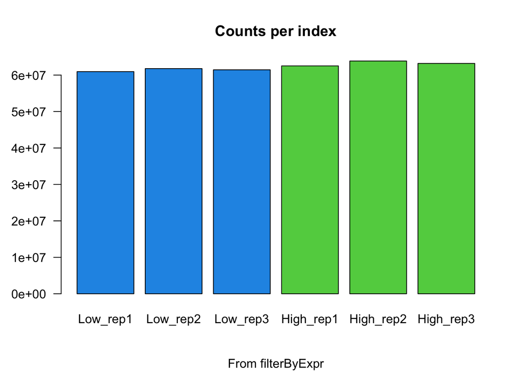

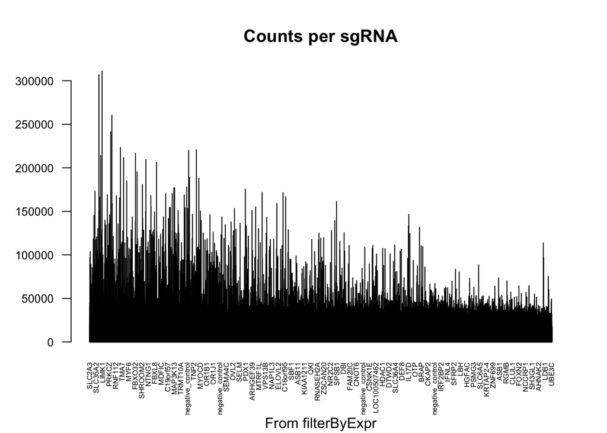

|  | Gene | Value |
| --- | --- | --- |
| 1247 | STMN2 | TRUE |
| 6426 | TARBP1 | TRUE |

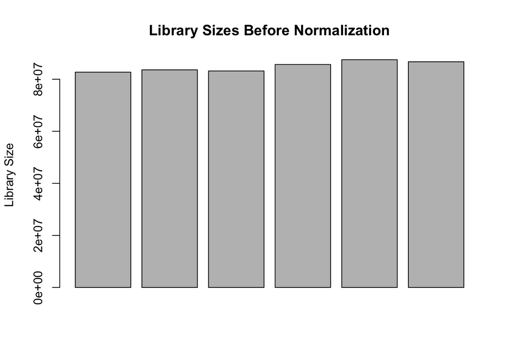

|  | group | lib.size | norm.factors | id | replicate |
| --- | --- | --- | --- | --- | --- |
| Low_rep1 | Low | 82720094 | 1.0114857 | 1 | 1 |
| Low_rep2 | Low | 83607428 | 1.0100516 | 2 | 2 |
| Low_rep3 | Low | 83174599 | 1.0088265 | 3 | 3 |
| High_rep1 | High | 85670261 | 0.9878532 | 4 | 1 |
| High_rep2 | High | 87504840 | 0.9856413 | 5 | 2 |
| High_rep3 | High | 86703451 | 0.9964807 | 6 | 3 |

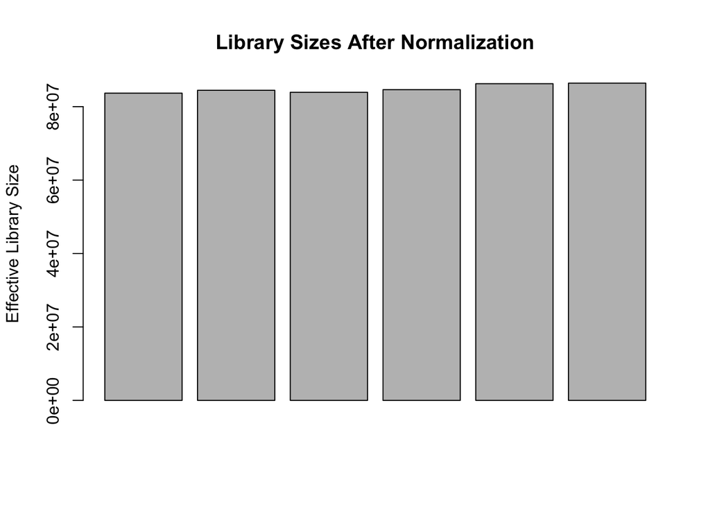

```
##   group      lib.size         norm.factors          id         replicate
##  High:3   Min.   :82720094   Min.   :0.9856   Min.   :1.00   Min.   :1.00
##  Low :3   1st Qu.:83282806   1st Qu.:0.9900   1st Qu.:2.25   1st Qu.:1.25
##           Median :84638844   Median :1.0027   Median :3.50   Median :2.00
##           Mean   :84896779   Mean   :1.0001   Mean   :3.50   Mean   :2.00
##           3rd Qu.:86445153   3rd Qu.:1.0097   3rd Qu.:4.75   3rd Qu.:2.75
##           Max.   :87504840   Max.   :1.0115   Max.   :6.00   Max.   :3.00
```

#### 1.3. Data Exploration.

Dimension 1 separates the high group from the low group, while dimension 2 (*maybe*) corresponds to the replicate number. The MDS plot (*maybe*) suggests that the samples were paired. The samples in the **High** group appear more heterogeneous than the samples in the **Low** group.

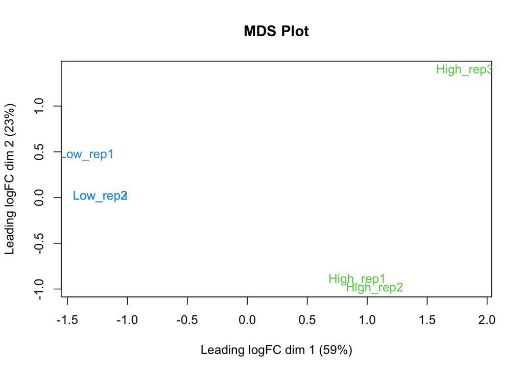

#### Sidebar

##### Paired/Blocking Designs

###### Paired Design

Clarify: Compare the High group to the Low group separately, so baseline differences between replicates are subtracted out. This test detects genes that are differentially expressed in response to the “active treatment” compared to the control, adjusting for baseline differences between replicates. TLDR; a generalization of a paired t-test.

```
## Coefficient:  replicate3
##                                gene
## MGEA5                         MGEA5
## LRP1                           LRP1
## RBBP8NL                     RBBP8NL
## GPR98                         GPR98
## HRCT1                         HRCT1
## negative_control.3 negative_control
## TMEM171                     TMEM171
## RDX                             RDX
## YTHDF2                       YTHDF2
## BTN1A1                       BTN1A1
##                                                                                         sgrna_id
## MGEA5                                        MGEA5_+_103578148.23-P1P2|MGEA5_+_103578106.23-P1P2
## LRP1                                             LRP1_-_57522313.23-P1P2|LRP1_-_57522286.23-P1P2
## RBBP8NL                                    RBBP8NL_+_61002537.23-P1P2|RBBP8NL_+_61002561.23-P1P2
## GPR98                                          GPR98_-_89854662.23-P1P2|GPR98_-_89854648.23-P1P2
## HRCT1                                          HRCT1_-_35906234.23-P1P2|HRCT1_-_35906330.23-P1P2
## negative_control.3                                       non-targeting_02456|non-targeting_01643
## TMEM171                                    TMEM171_-_72416420.23-P1P2|TMEM171_+_72416481.23-P1P2
## RDX                                              RDX_-_110167265.23-P1P2|RDX_+_110167318.23-P1P2
## YTHDF2                                       YTHDF2_+_29063507.23-P1P2|YTHDF2_+_29063483.23-P1P2
## BTN1A1             BTN1A1_-_26501474.23-ENST00000244513.6|BTN1A1_+_26501670.23-ENST00000244513.6
##                         logFC   logCPM        F      PValue       FDR
## MGEA5              -0.9086763 5.786920 15.89291 0.002257437 0.9994986
## LRP1                0.8884524 5.922651 14.34919 0.003159729 0.9994986
## RBBP8NL            -0.6827231 6.805769 13.69991 0.003664428 0.9994986
## GPR98               0.8286187 5.940644 13.66761 0.003691954 0.9994986
## HRCT1              -0.7815047 6.159861 13.51528 0.003825139 0.9994986
## negative_control.3  0.9209969 5.982924 13.14227 0.004176235 0.9994986
## TMEM171             1.2021983 5.463983 11.87929 0.005687846 0.9994986
## RDX                -0.8166376 5.708318 11.77252 0.005843414 0.9994986
## YTHDF2             -0.9175404 5.756273 10.78322 0.007555939 0.9994986
## BTN1A1              0.9981541 5.534540 10.29564 0.008618554 0.9994986
```

###### Blocked Design

Compare the two conditions (high/low) adjusting for differences between replicates by fitting an additive model: Primarily interested in the differences between “treatments” (high/low)

#### 1.4. Design Matrix - Block design

We will use the **blocked** design for the rest of the analysis

```
##   (Intercept) replicate2 replicate3 groupLow
## 1           1          0          0        1
## 2           1          1          0        1
## 3           1          0          1        1
## 4           1          0          0        0
## 5           1          1          0        0
## 6           1          0          1        0
## attr(,"assign")
## [1] 0 1 1 2
## attr(,"contrasts")
## attr(,"contrasts")$replicate
## [1] "contr.treatment"
##
## attr(,"contrasts")$group
## [1] "contr.treatment"
```

#### 1.5. Dispersion estimation

Options are *common dispersion*, *trended dispersion*, and *tagwise dispersion*. *common dispersion* best for small datasets with few replicates and does not account for differences based on expression level (ie assumes all genes have similar biological variability). *trended dispersion* best for larger datasets and suspect that variability depends on gene expression levels (eg low gene expression has higher noise). *tagwise dispersion* best for large datasets and builds on trended dispersion but also models individual gene variability (ie accounts for gene-specific variability).

*robust=true* argument: enables robust dispersion estimation, making the analysis less sensitive to outliers and genes with extreme variability. Useful for datasets with potential outliers or high variability and improves the stability and reliability of the dispersion estimates.

The square root of the common dispersion gives the coefficient of variation of the biological variation. Here, the **common dispersion** is **0.0558292** and the biological CV is **0.2362819**

In the BCV plot below:  
* The red line represents the common dispersion estimate. It assumes all genes have the same biological variability.  
* The blue line represents the trended dispersion estimate. It is the smoothed function of the relationship between the mean expression (log CPM) and the BCV.

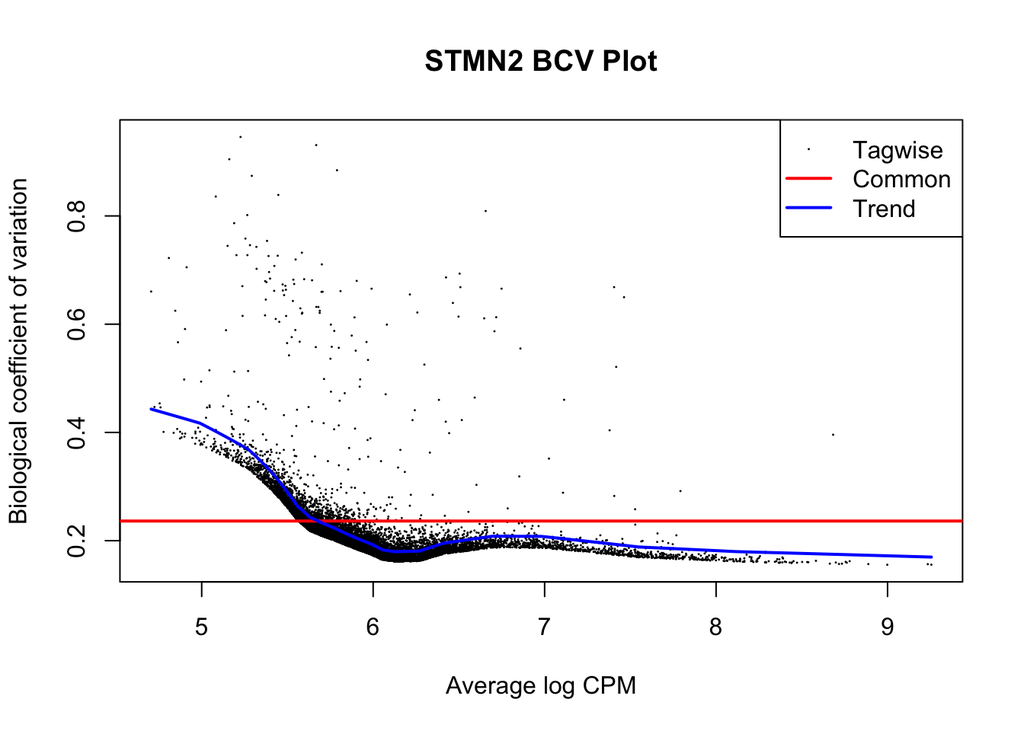

#### 1.6. Differential Expression Analysis

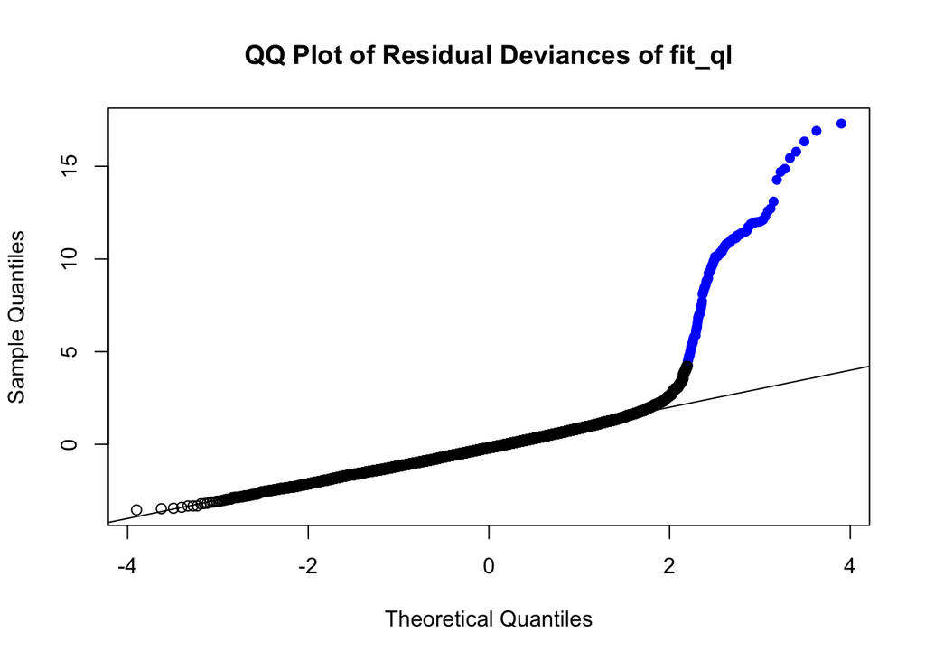

```
## Coefficient:  groupLow
##            gene                                              sgrna_id     logFC
## RANBP1   RANBP1   RANBP1_-_20105218.23-P1P2|RANBP1_-_20105086.23-P1P2  5.309154
## MAP2K4   MAP2K4   MAP2K4_-_11924225.23-P1P2|MAP2K4_+_11924171.23-P1P2 -5.767356
## CLASRP   CLASRP   CLASRP_-_45542349.23-P1P2|CLASRP_-_45542376.23-P1P2 -3.066021
## LARP6     LARP6     LARP6_+_71146449.23-P1P2|LARP6_-_71146443.23-P1P2  4.076255
## ATF2       ATF2     ATF2_+_176032892.23-P1P2|ATF2_+_176032497.23-P1P2 -4.801370
## CCNC       CCNC     CCNC_+_100016473.23-P1P2|CCNC_-_100016531.23-P1P2  4.821822
## CHORDC1 CHORDC1 CHORDC1_-_89955982.23-P1P2|CHORDC1_-_89955894.23-P1P2 -3.231431
## POU3F1   POU3F1   POU3F1_+_38512447.23-P1P2|POU3F1_+_38512374.23-P1P2 -3.068271
## MSL1       MSL1       MSL1_+_38278860.23-P1P2|MSL1_+_38278902.23-P1P2 -4.334287
## ZC3H13   ZC3H13   ZC3H13_-_46626846.23-P1P2|ZC3H13_+_46626889.23-P1P2  3.917611
##           logCPM        F       PValue          FDR
## RANBP1  7.589479 961.1384 8.154281e-12 8.521224e-08
## MAP2K4  7.563884 806.9072 2.055292e-11 9.754924e-08
## CLASRP  7.766241 760.9719 2.800457e-11 9.754924e-08
## LARP6   7.076813 686.4246 4.822997e-11 1.260008e-07
## ATF2    7.206023 654.5552 6.195356e-11 1.294829e-07
## CCNC    7.363661 618.9927 8.312923e-11 1.447834e-07
## CHORDC1 7.197657 572.3347 1.255155e-10 1.873768e-07
## POU3F1  7.618938 501.6797 2.506177e-10 3.273694e-07
## MSL1    6.161965 478.7563 3.202097e-10 3.717990e-07
## ZC3H13  7.571501 437.2919 5.143718e-10 5.375185e-07
```

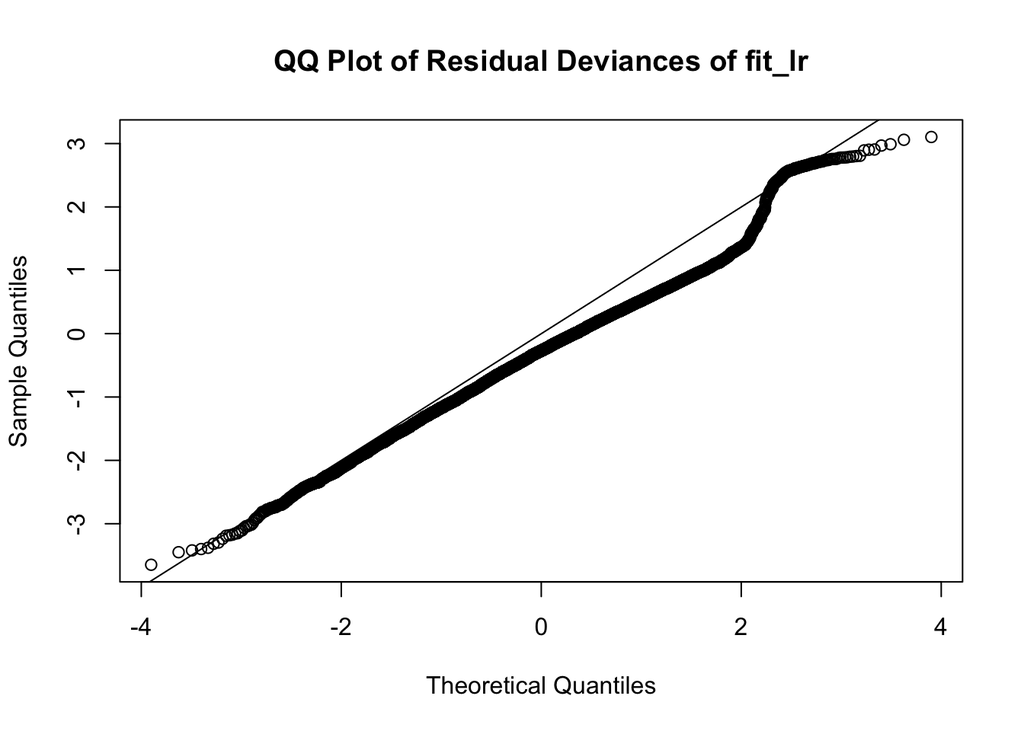

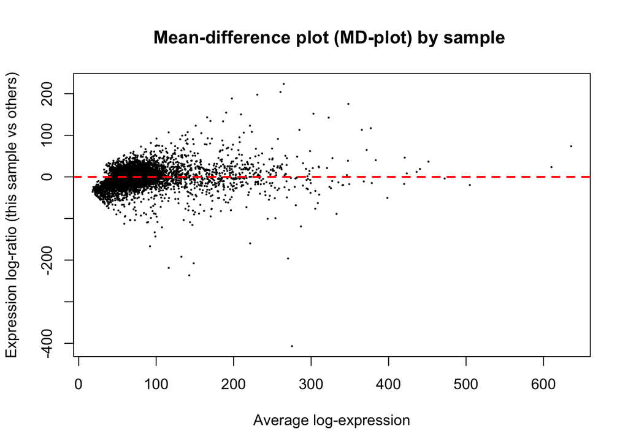

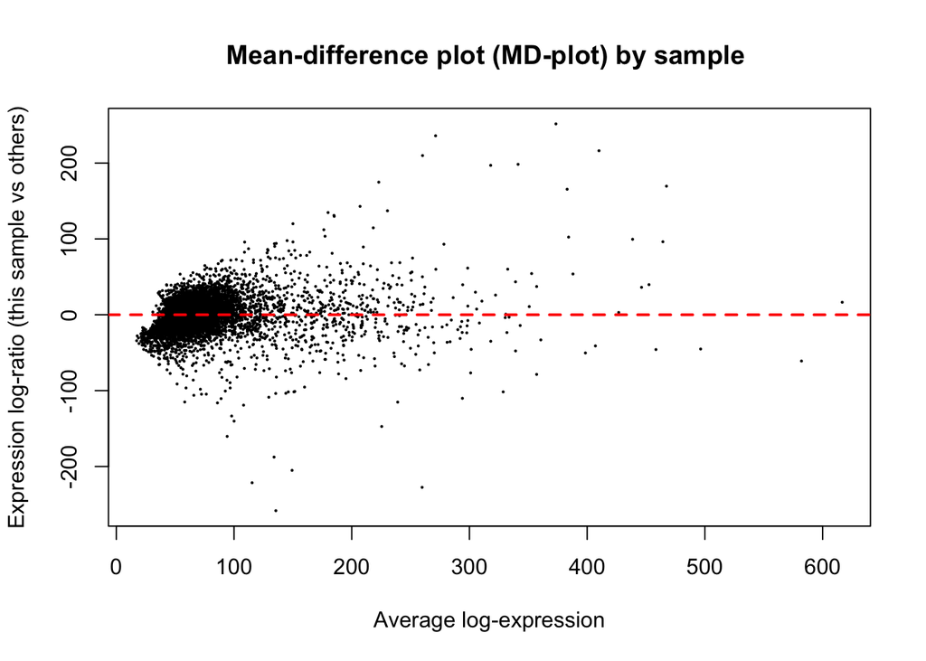

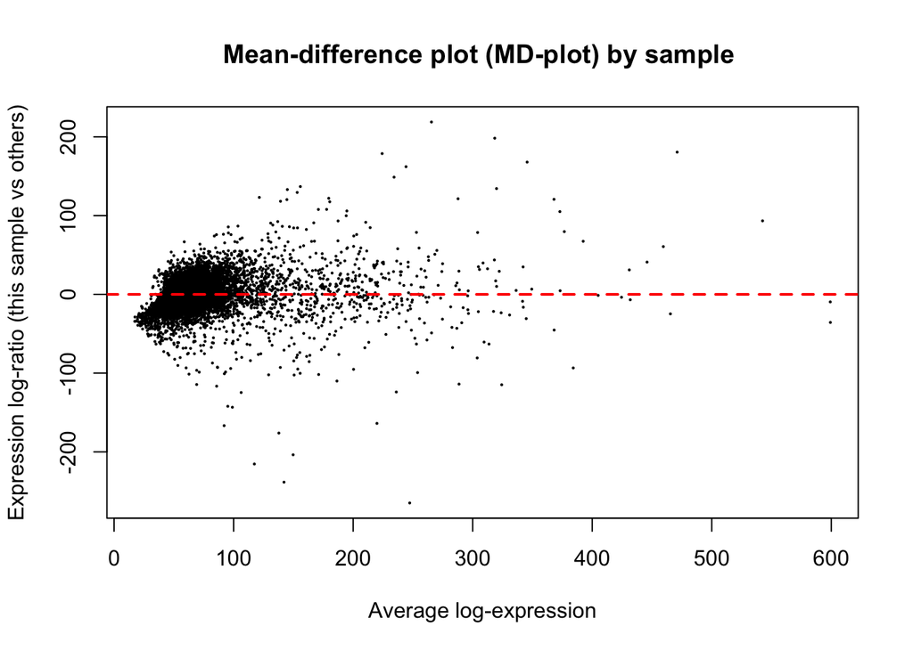

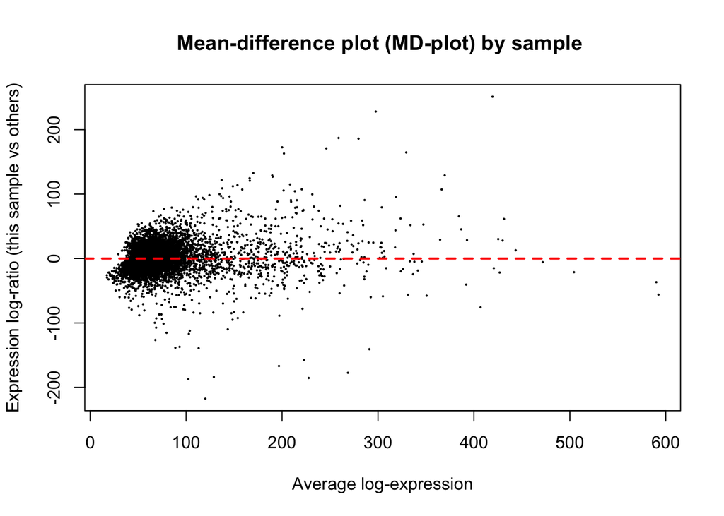

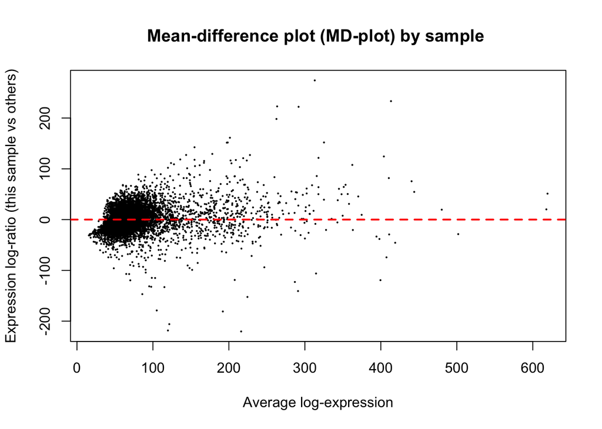

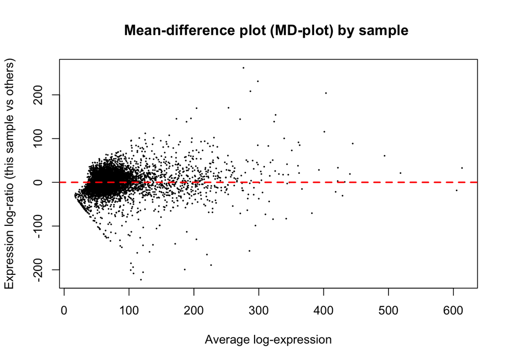

```
## Coefficient:  groupLow
##              gene                                                  sgrna_id
## RANBP1     RANBP1       RANBP1_-_20105218.23-P1P2|RANBP1_-_20105086.23-P1P2
## MAP2K4     MAP2K4       MAP2K4_-_11924225.23-P1P2|MAP2K4_+_11924171.23-P1P2
## MSL1         MSL1           MSL1_+_38278860.23-P1P2|MSL1_+_38278902.23-P1P2
## ATF2         ATF2         ATF2_+_176032892.23-P1P2|ATF2_+_176032497.23-P1P2
## CCNC         CCNC         CCNC_+_100016473.23-P1P2|CCNC_-_100016531.23-P1P2
## LARP6       LARP6         LARP6_+_71146449.23-P1P2|LARP6_-_71146443.23-P1P2
## DPH1.1       DPH1                 DPH1_-_1933503.23-P1|DPH1_-_1933469.23-P1
## KIAA1919 KIAA1919 KIAA1919_+_111580599.23-P1P2|KIAA1919_+_111580588.23-P1P2
## STAG3       STAG3         STAG3_+_99775559.23-P1P2|STAG3_-_99775579.23-P1P2
## ZC3H13     ZC3H13       ZC3H13_-_46626846.23-P1P2|ZC3H13_+_46626889.23-P1P2
##              logFC   logCPM       LR       PValue          FDR
## RANBP1    5.309076 7.589479 402.2762 1.759688e-89 1.838874e-85
## MAP2K4   -5.767489 7.563884 397.1324 2.318365e-88 1.211346e-84
## MSL1     -4.334204 6.161965 361.5102 1.320501e-80 4.599746e-77
## ATF2     -4.801440 7.206023 298.6772 6.396709e-67 1.671140e-63
## CCNC      4.821913 7.363661 297.0857 1.421364e-66 2.970650e-63
## LARP6     4.076243 7.076813 259.4872 2.219701e-58 3.865979e-55
## DPH1.1   -3.798226 6.040650 258.8985 2.982813e-58 4.452914e-55
## KIAA1919  5.116851 6.782499 236.8620 1.900823e-53 2.482950e-50
## STAG3    -3.815371 6.514625 232.6719 1.558299e-52 1.809358e-49
## ZC3H13    3.917658 7.571501 216.3656 5.612735e-49 5.865308e-46
```

All the top genes have consistent low vs high changes across replicates

```
## [1] "(Intercept)" "replicate2"  "replicate3"  "groupLow"
```

```
##            Low_rep1   Low_rep2   Low_rep3  High_rep1 High_rep2  High_rep3
## RANBP1   362.371557 389.212223 374.960320  11.283508  10.56027   7.095550
## MAP2K4     6.906559   4.635165   9.697471 331.629549 374.99637 407.271232
## MSL1       5.892854   7.099071   7.301926 134.653138 123.11398 151.408808
## ATF2       8.677757  14.037657   8.736691 283.475121 281.97246 288.837826
## CCNC     329.342610 310.357783 313.636949   8.717400  15.55968  10.432016
## LARP6    291.913515 247.278007 224.835278  19.472953  12.57875  13.790724
## DPH1      10.315280  11.838078   5.265073 127.605550 146.98820  92.809351
## KIAA1919 212.543785 210.064527 217.930474   4.677929  10.35975   4.815632
## STAG3     11.819128  10.997896  13.617452 173.463986 182.17127 156.369020
## ZC3H13   376.318351 365.111255 325.307221  36.969144  18.58072  18.884395
```

The total number of genes with a FDR < 0.05 is **783, 9063, 604**.  
The total number of genes with a logFC < -1 is **520**.  
The total number of genes with a logFC > 1 is **387**.

### Experiment 2: Try analysis with glmQLFit and glmLRT functions. Differs from the experiment above as this experiment uses glmQLFit followed by glmLRT functions for the analysis which resulted in TDP and STMN2 being listed as a top hit in analysis.

#### 2.1 Reading in the data

#### 2.2. Filtering and Normalization

```
## keep
## FALSE  TRUE
##   599 20513
```

*From Analyzing data from pooled genetic sequencing screens using edgeR,* **Chapt 2** *Analysis of a small shRNA-seq screen*

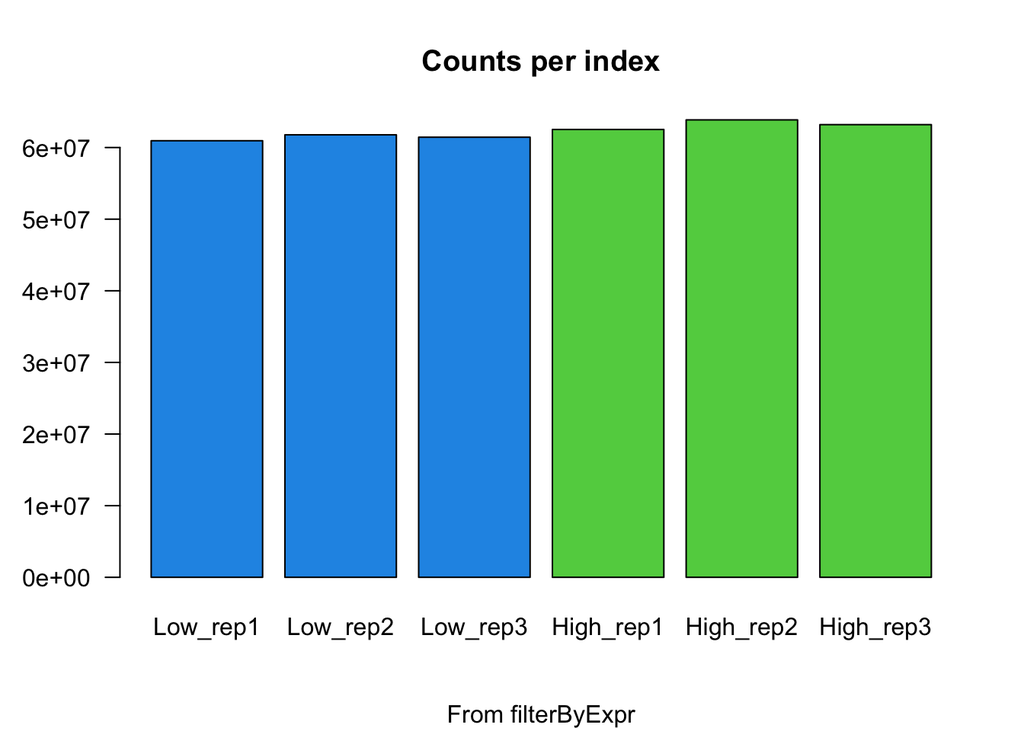

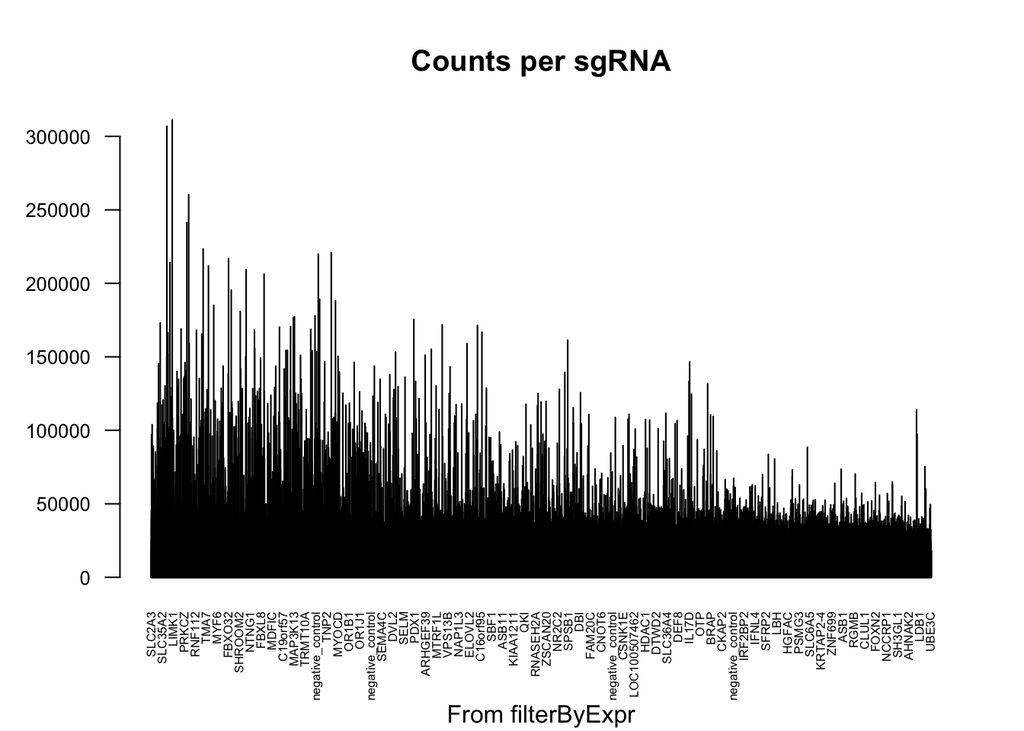

|  | Gene | Value |
| --- | --- | --- |
| 1724 | STMN2 | TRUE |
| 9505 | TARBP1 | TRUE |

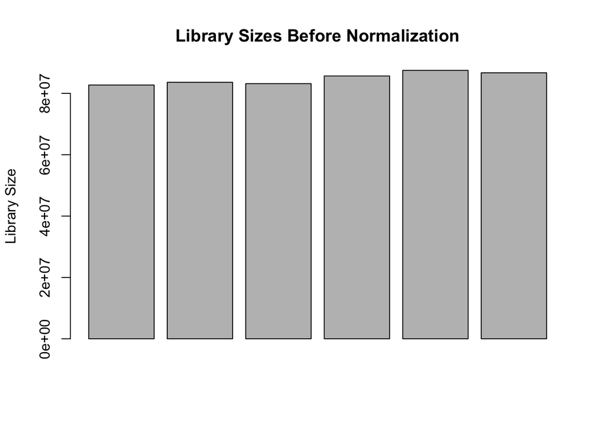

|  | group | lib.size | norm.factors | id | replicate |
| --- | --- | --- | --- | --- | --- |
| Low_rep1 | Low | 82720094 | 1.0114857 | 1 | 1 |
| Low_rep2 | Low | 83607428 | 1.0100516 | 2 | 2 |
| Low_rep3 | Low | 83174599 | 1.0088265 | 3 | 3 |
| High_rep1 | High | 85670261 | 0.9878532 | 4 | 1 |
| High_rep2 | High | 87504840 | 0.9856413 | 5 | 2 |
| High_rep3 | High | 86703451 | 0.9964807 | 6 | 3 |

```
##   group      lib.size         norm.factors          id         replicate
##  High:3   Min.   :82720094   Min.   :0.9856   Min.   :1.00   Min.   :1.00
##  Low :3   1st Qu.:83282806   1st Qu.:0.9900   1st Qu.:2.25   1st Qu.:1.25
##           Median :84638844   Median :1.0027   Median :3.50   Median :2.00
##           Mean   :84896779   Mean   :1.0001   Mean   :3.50   Mean   :2.00
##           3rd Qu.:86445153   3rd Qu.:1.0097   3rd Qu.:4.75   3rd Qu.:2.75
##           Max.   :87504840   Max.   :1.0115   Max.   :6.00   Max.   :3.00
```

#### 2.3. Data Exploration

Dimension 1 separates the high group from the low group, while dimension 2 (*maybe*) corresponds to the replicate number. The MDS plot (*maybe*) suggests that the samples were paired. The samples in the **High** group appear more heterogeneous than the samples in the **Low** group.

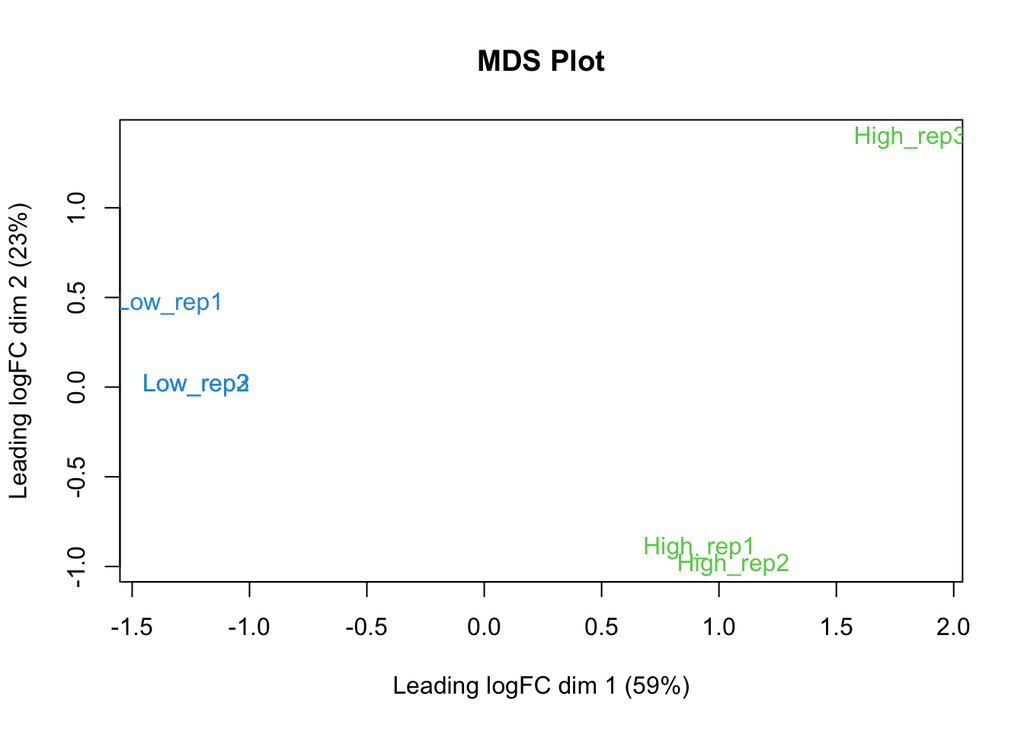

#### 2.4. Design Matrix - Block design

Compare the two conditions (high/low) adjusting for differences between replicates by fitting an additive model:  
Primarily interested in the differences between “treatments” (high/low). *Differences between replicates are not of primary interest, nor are we interested in a “treatment” effect that occurs for one replicate as this is not reproducible.*

**Interestingly, glmQLFit followed by glmLRT top tags results in TDP43 and STMN2 - but dont know why…

```r
group <- factor(dge$samples$group)
replicate <- factor(dge$samples$replicate)
block_design_mat <- model.matrix(~replicate + group)
```

#### 2.5. Dispersion estimation

The square root of the common dispersion gives the coefficient of variation of the biological variation. Here, the **common dispersion** is **0.0558292** and the biological CV is **0.2362819**

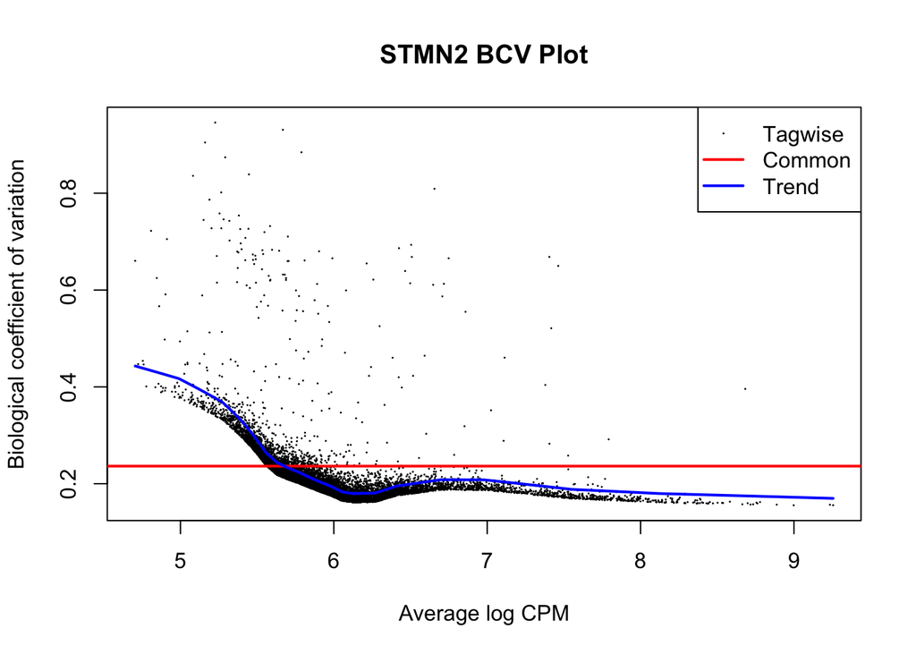

#### 2.6. Differential Expression Analysis

```
## Coefficient:  groupLow
##          gene                                            sgrna_id     logFC
## PRMT2   PRMT2   PRMT2_-_48056006.23-P1P2|PRMT2_+_48055615.23-P1P2  6.866502
## TARDBP TARDBP TARDBP_-_11072919.23-P1P2|TARDBP_+_11072781.23-P1P2  6.161969
## MAP2K4 MAP2K4 MAP2K4_-_11924225.23-P1P2|MAP2K4_+_11924171.23-P1P2 -5.767356
## TAF4     TAF4     TAF4_+_60640894.23-P1P2|TAF4_+_60640814.23-P1P2  6.418888
## STMN2   STMN2   STMN2_+_80523371.23-P1P2|STMN2_+_80523383.23-P1P2  5.869448
## ASNA1   ASNA1   ASNA1_+_12848373.23-P1P2|ASNA1_+_12848657.23-P1P2 -5.973484
## UBE3C   UBE3C UBE3C_-_156932395.23-P1P2|UBE3C_-_156931660.23-P1P2 -6.045312
## CNOT3   CNOT3   CNOT3_+_54641532.23-P1P2|CNOT3_-_54641691.23-P1P2 -6.292510
## RANBP1 RANBP1 RANBP1_-_20105218.23-P1P2|RANBP1_-_20105086.23-P1P2  5.309154
## GSTO1   GSTO1 GSTO1_-_106015047.23-P1P2|GSTO1_-_106015033.23-P1P2  5.647264
##          logCPM       LR        PValue           FDR
## PRMT2  5.660893 501.4811 4.525989e-111 4.729658e-107
## TARDBP 6.045884 437.4144  3.955209e-97  2.066597e-93
## MAP2K4 7.563884 418.8229  4.402068e-93  1.533387e-89
## TAF4   4.902805 409.6101  4.456536e-91  1.164270e-87
## STMN2  6.330721 407.2960  1.421391e-90  2.970707e-87
## ASNA1  5.142018 402.6682  1.445784e-89  2.518074e-86
## UBE3C  6.592209 398.9176  9.474728e-89  1.414442e-85
## CNOT3  4.846021 384.9049  1.064422e-85  1.390402e-82
## RANBP1 7.589479 372.2224  6.142099e-83  7.131659e-80
## GSTO1  5.189972 369.7203  2.153205e-82  2.250099e-79
```

All the top genes have consistent low vs high changes across replicates

```
## [1] "(Intercept)" "replicate2"  "replicate3"  "groupLow"
```

```
##           Low_rep1    Low_rep2    Low_rep3   High_rep1   High_rep2   High_rep3
## PRMT2  101.1922295  95.1011164 103.7257844   0.6261795   0.3208182   2.4689845
## TARDBP 133.8647096 125.9613060 129.6155967   2.2100451   4.1171669   0.5115914
## MAP2K4   6.9065590   4.6351646   9.6974705 331.6295487 374.9963696 407.2712322
## TAF4    38.8883832  62.3151151  74.6974248   2.9221708   0.2272462   0.3114035
## STMN2  169.7008393 118.7111911 183.0605730   7.0844224   0.5346970   3.7145983
## ASNA1    0.1002565   1.9541325   2.0368531  81.1332121  74.2694125  52.2156864
## UBE3C    2.5175522   0.6513775  12.0673940 197.9709309 195.1911378 170.3488111
## CNOT3    4.8345913   0.2265661   0.2049664  49.5418448  59.1909573  58.4103908
## RANBP1 362.3715573 389.2122225 374.9603198  11.2835082  10.5602656   7.0955501
## GSTO1   71.9173309  48.3152188  92.0939439   4.6902069   0.1871439   1.6904759
```

The total number of genes with a FDR < 0.05 is **972, 8651, 827**. The total number of genes with a logFC < -1 is **519**. The total number of genes with a logFC > 1 is **385**.